# TLDR

Major lessons learned here:

1. We need to go through subcategories and check for typos and alike.
2. We might have to take some hit and miss matches to avoid false positives as much as possible, for example in small words single character mismatch => similarity below 0.9, but that is supposed to be tackled by introduced jaro winkler algorithm into the system, on top of Levenshtein.
3. Absolute majority of matches don't require algorithmic check as subcategory names are mostly substrings of titles - 92.4%, 232 out of 251.
4. BUT 7.6% of similarities found by employing algorithms means 203 events categorized **properly*, allegedly.

```python
jj_unique
```

|  | title | title_sub | subcat | similarity | jaro_winkler |
| --- | --- | --- | --- | --- | --- |
| 0 | Army Black Knights Football vs. Buffalo Bulls ... | Buffalo Bulls | Buffalo Bills | 0.857143 | 0.969231 |
| 2 | Lehigh Valley IronPigs at Scranton Wilkes-Barr... | Lehigh Valley IronPigs at | Lehigh Valley Iron Pigs | 0.920000 | 0.000000 |
| 3 | Pawtucket Red Sox at Lehigh Valley IronPigs | at Lehigh Valley IronPigs | Lehigh Valley Iron Pigs | 0.920000 | 0.000000 |
| 20 | Norfolk Tides vs. Lehigh Valley IronPigs | vs Lehigh Valley IronPigs | Lehigh Valley Iron Pigs | 0.920000 | 0.000000 |
| 31 | Omaha Storm Chasers at Memphis Redbirds | Memphis Redbirds | Memphis Red Birds | 0.833333 | 0.963971 |
| 48 | Tacoma Rainiers at Sacramento River Cats | Sacramento River Cats | Sacremento River Cats | 0.909091 | 0.000000 |
| 86 | Lehigh Valley IronPigs at Scranton Wilkes-Barr... | Scranton Wilkes Barre RailRiders | Scranton Wilkes-Barre Rail Riders | 0.969697 | 0.000000 |
| 127 | Pawtucket Redsox vs. Toledo Mudhens | Toledo Mudhens | Toledo Mud Hens | 0.812500 | 0.959048 |
| 129 | Boston Symphony Orchestra: Andris Nelsons cond... | Yo Yo Ma | Yo Yo Ma | 1.000000 | 0.000000 |
| 131 | Yo-Yo Mas Goat Rodeo Sessions featuring Stuart... | Yo Yo Mas | Yo Yo Ma | 0.888889 | 0.977778 |
| 134 | Aint Too Proud New York | Aint Too Proud | Ain't Too Proud | 0.933333 | 0.000000 |
| 138 | Come from Away | Come from Away | Come From Away | 0.866667 | 0.971429 |
| 139 | Kiss Me Kate Lincolnshire | Kiss Me Kate | Kiss Me, Kate | 0.923077 | 0.000000 |
| 140 | Moulin Rouge The Musical New York | Moulin Rouge | Moulin Rouge! | 0.923077 | 0.000000 |
| 143 | Oklahoma City Philharmonic: Gritty, Sweet And ... | Oklahoma | Oklahoma! | 0.888889 | 0.977778 |
| 152 | The Bands Visit Durham | The Bands Visit | The Band's Visit | 0.937500 | 0.000000 |
| 172 | Chris DElia | Chris DElia | Chris D'Elia | 0.916667 | 0.000000 |
| 178 | Iliza Shlesinger | Iliza Shlesinger | Iliza Schesinger | 0.882353 | 0.975000 |
| 193 | Jim Jefferies | Jim Jefferies | Jim Jeffries | 0.923077 | 0.000000 |

Jaro winkler is complementary check if 0.8 < similarity < 0.9.

> Summary

```
| Type of match  | Number of matches |
|----------------+-------------------|
| algorithm(s)   |                19 |
| exact [substr] |               232 |
|----------------+-------------------|
| Total          |               251 |
```

# Details

```python
import pandas as pd
import re
import os
from typing import List
# extraction
import datetime
import textdistance as td
import re
```

```python
REGEX = re.compile('[a-zA-Z0-9]\w+')


SIM_CHECK = []
MATCHES = []


def combinations(title: str, name: str) -> List:
    """Make combinations out of title,
    n of elements in combination = length of original subcategory name
    ex:
    title: Pik Floyd live in Pompeii
    name: Pink Floyd
    title will turn into: ['Pink Floyd', 'Floyd live', 'Live in', 'in Pompeii']"""
    global REGEX
    t = REGEX.findall(title)
    n = len(name.split())
    combine = lambda i: ' '.join(t[i:i + n])
    return list(map(combine, range(len(t))))


def check_similarity(title: str, name: str) -> bool:
    """
    Checking title and name similarity.
    1. we check if name is a substring of title,
    2. if not then we move to more computationally demanding process
       of calculating similarity distance between 2 strings.
       in this case between combinations of title and name.
    """
    if name in title:
        return True
    # 2. run similarity measurement
    else:
        # create combinations from title, n = length of name
        for t in combinations(title, name):
            jsim = 0
            sim = td.damerau_levenshtein.normalized_similarity(t, name)
            if sim > 0.8 and sim < 0.9:
                jsim = td.jaro_winkler.normalized_similarity(t, name)
            if sim >= 0.9 or jsim >= 0.95:
                print(f'similarity: {sim}, title: {title}, event: {t}={name} :subcat')
                MATCHES.append({'title': title, 'title_sub': t, 'subcat': name, 'similarity': sim})
                return True
        return False

def extract_subcategory(events, subcategories):
    """
    getting title column from yey_event table, out of title we infer subcategory id.
    """
    # getting unique titles which decreases computation time significantly.
    unique_titles = events.drop_duplicates('title')[['title', 'category_id', 'subcategory_id']]
    #unique_titles = events[['title', 'category_id', 'subcategory_id']]
    subcategories = zip(subcategories['id'],
                        subcategories['name'],
                        subcategories['category_id'])

    # Collecting SIM_CHECK data for analysis.
    global SIM_CHECK
    # Currently these categories tend to falkl under 21, Theaer.
    # 18 Latin, 20 Classical, 22 Comedy
    # Hence including all these into the hunting process is a sound approach.
    common_arts = [18, 20, 21, 22]

    # Iterating over each subcategory to find its peers
    for subcat_id, subcat_name, cat_id in subcategories:
        if cat_id in common_arts:
            tmp = unique_titles[unique_titles['category_id'].isin(common_arts)]
        else:
            tmp = unique_titles[unique_titles['category_id'] == cat_id]

        # generating boolean map anf filtering out the data
        tmp = tmp[tmp['title'].map(lambda title: check_similarity(title, subcat_name))]

        # if results where found then assign subcategory_id to unique_titles
        if len(tmp) != 0:
            print(f'subcat_name: {subcat_name}')
            SIM_CHECK.append({'cat_id': cat_id, 'subcat_name': subcat_name, 'subcat_id': subcat_id})
            unique_titles.loc[tmp.index, 'subcategory_id'] = int(subcat_id)

    # Well, this is a clumsy bit of code, trade-off to avoid processing whole dataset.
    # Since we extracted unique titles, right now we gotta give it back and fill out subcategories
    # for the title duplicates as well (they might differ in time, venue etc)
#     self.events.drop(columns=['subcategory_id'], inplace=True)
#     self.events = pd.merge(self.events, unique_titles, on=['title'])
#     rewrite_categories = lambda row: row['category_id_y'] if row['subcategory_id'] else row['category_id_x']
#     self.events['category_id'] = self.events.apply(rewrite_categories, axis=1)
#     self.events.drop(columns=['category_id_x', 'category_id_y'], inplace=True)
```

```python
events = pd.read_csv("data/yey_event.csv")
events = events[~events['title'].str.contains('PARKING')]

subcats = pd.read_csv("data/yey_subcategory.csv")
cats = pd.read_csv('data/yey_category.csv')
```

# What question are we trying to answer here?

- Figure out if 45K nulls in subcategories make sense
- How does a title pop up above the threshold? Why?
- How many subcategories wheren't matched with title in yey_event and which categories?¶

#### One way of checking it is similarity check with lower barrier, and then analyse false positives and false negatives.

```python
%time extract_subcategory(events, subcats)
```

- 3 mins 33s [w/duplicates included]

# 1. How many subcategories wheren't matched with title in `yey_event` and which categories?

```python
sim = pd.DataFrame(SIM_CHECK)

matches = sim.groupby('cat_id').count()['subcat_name'].reset_index()
scats = subcats.groupby('category_id').count()['id'].reset_index()
matches.rename(columns={'cat_id': 'category_id'}, inplace=True)
cats.rename(columns={'id': 'category_id'}, inplace=True)
sim_data = matches.merge(scats, how='outer').merge(cats, on='category_id')
```

```python
sim_data = sim_data.rename(columns={'id': 'subcategory_count', 'name': 'category_name', 'subcat_name': 'matches_in_data'})[['category_id', 'category_name', 'subcategory_count', 'matches_in_data']]
```

```python
sim_data['matched'] = sim_data.apply(lambda row: row['matches_in_data'] / row['subcategory_count'] * 100, axis=1)
```

```python
sim_data
```

|  | category_id | category_name | subcategory_count | matches_in_data | matched |
| --- | --- | --- | --- | --- | --- |
| 0 | 1 | Football | 62 | 25.0 | 40.322581 |
| 1 | 2 | Baseball | 60 | 55.0 | 91.666667 |
| 2 | 3 | Basketball | 60 | 5.0 | 8.333333 |
| 3 | 4 | Hockey | 62 | 25.0 | 40.322581 |
| 4 | 12 | Hip Hop | 50 | 12.0 | 24.000000 |
| 5 | 13 | Country | 50 | 38.0 | 76.000000 |
| 6 | 18 | Latin | 50 | 1.0 | 2.000000 |
| 7 | 20 | Classical | 50 | 21.0 | 42.000000 |
| 8 | 21 | Theater | 50 | 33.0 | 66.000000 |
| 9 | 22 | Comedy | 49 | 40.0 | 81.632653 |
| 10 | 5 | Tennis | 50 | NaN | NaN |
| 11 | 6 | Soccer | 39 | NaN | NaN |
| 12 | 7 | Golf | 50 | NaN | NaN |
| 13 | 8 | Wrestling | 50 | NaN | NaN |
| 14 | 9 | Boxing | 85 | NaN | NaN |
| 15 | 10 | Rock | 50 | NaN | NaN |
| 16 | 11 | Pop | 50 | NaN | NaN |
| 17 | 14 | R&B | 50 | NaN | NaN |
| 18 | 15 | Electronic | 50 | NaN | NaN |
| 19 | 16 | Jazz | 50 | NaN | NaN |
| 20 | 17 | Blues | 50 | NaN | NaN |
| 21 | 19 | Christian | 50 | NaN | NaN |

```python
sim_data = pd.read_csv('data/sim_data_jaro_jac.csv')
```

```python
sim_data['matches_in_data'].sum()
```

```
251.0
```

```python
sim_data['subcategory_count'].sum() - sim_data['matches_in_data'].sum()
```

```
916.0
```

> Matched 251, not matched 916. A major reason I think is the **absence** of events in general.

```python
import matplotlib.pyplot as plt
plt.rcParams["figure.figsize"] = (12,8)
```

```
<BarContainer object of 22 artists>
```

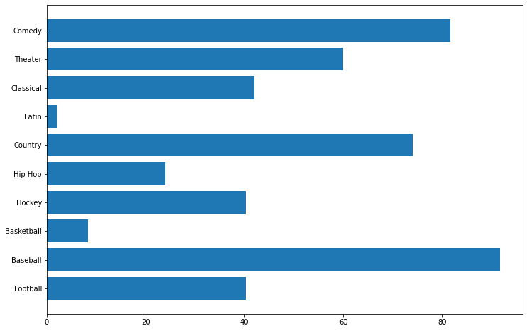

```python
plt.barh(sim_data['category_name'], sim_data['matched'])
```

# 2. How does a title pop up above the threshold?

Currently, for a bigger picture I set to 0.9 and 0.95 for Jaccard and Jaro-Winkler respectively.

```python
matches.sample(5)
```

|  | title | title_sub | subcat | similarity |
| --- | --- | --- | --- | --- |
| 19 | Lehigh Valley IronPigs at Norfolk Tides | Lehigh Valley IronPigs at | Lehigh Valley Iron Pigs | 0.920000 |
| 105 | Scranton/Wilkes-Barre RailRiders vs. Syracuse ... | Scranton Wilkes Barre RailRiders | Scranton Wilkes-Barre Rail Riders | 0.969697 |
| 175 | Chris DElia Tickets (21+ Event, Rescheduled fr... | Chris DElia | Chris D'Elia | 0.916667 |
| 54 | Sacramento River Cats at El Paso Chihuahuas | Sacramento River Cats | Sacremento River Cats | 0.909091 |
| 183 | Iliza Shlesinger Tickets (Rescheduled from Mar... | Iliza Shlesinger | Iliza Schesinger | 0.882353 |

```python
matches.shape
```

```
(203, 4)
```

So, to say a few words what's going on in here.

1. **title**: a complete title from `yey_event`
2. **title_sub**: combination of words generated from title for comparison reasons. 2.1 combinations length == subcategory name length in `yey_subcategory`, so if we have `Moulin Rouge!`, then we generate 2 word combinations from title: `Moulin Rouge`, `Rouge The`, `The Musical` etc. Here we generally partition title elements by 2 progressively, one step at a time.
3. **subcat**: subcategory name
- How does algorithm works?
  1. If Jaccard similarity index is >= 0.9 (in this case) then we think that substring of title and subcategory name do match each other enough and we add subcategory_id value to the column with same name in `yey_event`.
  2. If 0.80 < `Jaccard index` < 0.9: then we are double checking the match using `Jaro Winkler` method, with this approach we're catching typos in small strings such as: `iliza sh*L*esinger` and `iliza schesinger`, in this very case a typo is in our `yey_subcategory` table, though.
- 203 matches with unique titles.
- For perhaps (reasonable) speed, which increases the pefromance roughly 6 fold, I deduplicate the data according titles -> 65K goes down to -> 10K, and then we merge subcategory and category records over the original dataframe `yey_event` table. Nonetheless processing of 10K events for 1.3K categories took **3 mins 33 secs** on MBP 15" i7 (6th gen).
- We gotta discuss this, and perhaps find a way to a better performance.

# Not necessiraly important.

> Past approach and larger analysis with only DL algorithm. You can ignore this section, and jump to Jaro Winkler exploration.

```python
matches.sort_values('lev_similarity', inplace=True)
```

```python
matches.shape
```

```
(1778, 4)
```

```python
f = lambda s1, s2: [set(s1.split()).difference(set(s2.split())), set(s2.split()).difference(set(s1.split()))]
```

```python
sim_f = lambda tb, tu, dist: dist[(dist['lev_similarity'] < tu) & (dist['lev_similarity'] > tb)].drop_duplicates('title_sub').sort_values('lev_similarity', ascending=False)
```

# (Yet) our favourite: Damrau Levenshtein algorithm

# sim < 0.8

So, Looking at the top results below 80%, we can say that the treshold is way too low, no actual matches were found.

```python
sim_f(0, 0.8)
```

|  | title | title_sub | subcat | lev_similarity |
| --- | --- | --- | --- | --- |
| 299 | Texas Rangers at Los Angeles Angels | Los Angeles Angels | Los Angeles Dodgers | 0.789474 |
| 111 | Washington Huskies Football vs. Utah State Agg... | Washington Huskies | Washington Redskins | 0.789474 |
| 35 | Cincinnati Bearcats Football vs. Western Michi... | Cincinnati Bearcats | Cincinnati Bengals | 0.789474 |
| 188 | PARKING PASSES ONLY Cleveland Indians at Los A... | Los Angeles Dodgers | Los Angeles Angels | 0.789474 |
| 1228 | PARKING PASSES ONLY Metropolitan Opera Tickets... | Metropolitan Opera Tickets | Metropolitan Opera Orchestra | 0.785714 |
| ... | ... | ... | ... | ... |
| 551 | In the Den: Pixie & The Partygrass Boys plus B... | Boys plus | Ross Ellis | 0.700000 |
| 540 | Rehab, Slum City Kings | City Kings | City Girls | 0.700000 |
| 544 | KOTA The Friend with Special Guests Marlon Cra... | The Friend | The Weeknd | 0.700000 |
| 552 | Philadelphia Orchestra : Bugs Bunny at the Sym... | Bugs Bunny | Bad Bunny | 0.700000 |
| 1777 | Tim Dillon Tickets (21+ Event) | Tim Dillon | Tim Allen | 0.700000 |

149 rows × 4 columns

# 0.9 < sim < 0.8

```python
sim_f(0.79, 0.9)
```

|  | title | title_sub | subcat | lev_similarity |
| --- | --- | --- | --- | --- |
| 1687 | Dear Evan Hansen Oklahoma City | Oklahoma | Oklahoma! | 0.888889 |
| 1633 | Yo-Yo Mas Goat Rodeo Sessions featuring Stuart... | Yo Yo Mas | Yo Yo Ma | 0.888889 |
| 1743 | Iliza Shlesinger Tickets | Iliza Shlesinger | Iliza Schesinger | 0.875000 |
| 170 | Toledo Mud Hens at Lehigh Valley IronPigs | at Lehigh Valley IronPigs | Lehigh Valley Iron Pigs | 0.840000 |
| 169 | Lehigh Valley IronPigs at Columbus Clippers | Lehigh Valley IronPigs at | Lehigh Valley Iron Pigs | 0.840000 |
| 167 | Scranton/Wilkes-Barre RailRiders vs. Lehigh Va... | vs Lehigh Valley IronPigs | Lehigh Valley Iron Pigs | 0.840000 |
| 1651 | The Addams Family Hagerstown | Hagerstown | Hadestown | 0.800000 |
| 542 | Burna Boy- Twice As Tall Tour | Burna | Gunna | 0.800000 |
| 537 | PARKING PASSES ONLY Montreal Canadiens at Toro... | Toronto Maple | Toronto Marlies | 0.800000 |
| 51 | Michigan Wolverines Football vs. Ball State Ca... | Ball State Cardinals | Iowa State Cardinals | 0.800000 |
| 535 | TBD at Edmonton Oil Kings: WHL Playoffs Round ... | Edmonton Oil | Edmonton Oilers | 0.800000 |

# 1 < sim < 0.89

```python
sim_f(0.89, 1.1)
```

|  | title | title_sub | subcat | lev_similarity |
| --- | --- | --- | --- | --- |
| 1632 | Not Our First Goat Rodeo with Yo-Yo Ma, Stuart... | Yo Yo Ma | Yo Yo Ma | 1.000000 |
| 398 | Fresno Grizzlies at Sacramento River Cats | Sacramento River Cats | Sacremento River Cats | 0.952381 |
| 1711 | The Book Of Mormon (New York, NY) | The Book Of Mormon | The Book of Mormon | 0.944444 |
| 468 | Scranton/Wilkes-Barre RailRiders vs. Pawtucket... | Scranton Wilkes Barre RailRiders | Scranton Wilkes-Barre Rail Riders | 0.939394 |
| 1727 | What The Constitution Means To Me (Chicago) | What The Constitution Means To Me | What the Constitution Means to Me | 0.939394 |
| 1691 | The Bands Visit Appleton | The Bands Visit | The Band's Visit | 0.937500 |
| 1637 | Aint Too Proud New York | Aint Too Proud | Ain't Too Proud | 0.933333 |
| 1648 | Come from Away | Come from Away | Come From Away | 0.928571 |
| 1671 | Moulin Rouge The Musical New York | Moulin Rouge | Moulin Rouge! | 0.923077 |
| 1757 | Jim Jefferies | Jim Jefferies | Jim Jeffries | 0.923077 |
| 1 | Kansas State Wildcats Football vs. Buffalo Bul... | Buffalo Bulls | Buffalo Bills | 0.923077 |
| 1670 | Kiss Me Kate Lincolnshire | Kiss Me Kate | Kiss Me, Kate | 0.923077 |
| 1732 | Chris DElia Tickets (21+ Event) | Chris DElia | Chris D'Elia | 0.916667 |

```python
sim_data['matches_in_data'].sum() # this one includes all that has sim index > 0.7.
```

```
251.0
```

```python
td.damerau_levenshtein.normalized_similarity('Lehigh Valley IronPigs at', 'Lehigh Valley Iron Pigs')
```

```
0.84
```

```python
td.hamming.normalized_similarity('Lehigh Valley IronPigs at', 'Lehigh Valley Iron Pigs')
```

```
0.72
```

```python
td.damerau_levenshtein.normalized_similarity('Lehigh Valley IronPigs', 'Lehigh Valley Iron Pigs')
```

```
0.9565217391304348
```

```python
td.cosine.normalized_similarity('Lehigh Valley IronPigs', 'Lehigh Valley Iron Pigs')
```

```
0.9780192938436515
```

- This was just an illustration of tradeoff between precision and time.
  - Hamming - find how many characters are equal on the same index
  - Damerau Levenshtein - looking for how many changes do we need to make 2 strings equal.

Time diff. on my MBP [i7 6th gen] - Hamming - 3 mins, Damerau Levenshtein - 35 mins.

```python
matches[matches['lev_similarity'] >= 0.9].drop_duplicates('subcat')
```

|  | title | title_sub | subcat | lev_similarity |
| --- | --- | --- | --- | --- |
| 1732 | Chris DElia Tickets (21+ Event) | Chris DElia | Chris D'Elia | 0.916667 |
| 1671 | Moulin Rouge The Musical New York | Moulin Rouge | Moulin Rouge! | 0.923077 |
| 1757 | Jim Jefferies | Jim Jefferies | Jim Jeffries | 0.923077 |
| 1 | Kansas State Wildcats Football vs. Buffalo Bul... | Buffalo Bulls | Buffalo Bills | 0.923077 |
| 1670 | Kiss Me Kate Lincolnshire | Kiss Me Kate | Kiss Me, Kate | 0.923077 |
| 1648 | Come from Away | Come from Away | Come From Away | 0.928571 |
| 1637 | Aint Too Proud New York | Aint Too Proud | Ain't Too Proud | 0.933333 |
| 1691 | The Bands Visit Appleton | The Bands Visit | The Band's Visit | 0.937500 |
| 468 | Scranton/Wilkes-Barre RailRiders vs. Pawtucket... | Scranton Wilkes Barre RailRiders | Scranton Wilkes-Barre Rail Riders | 0.939394 |
| 1727 | What The Constitution Means To Me (Chicago) | What The Constitution Means To Me | What the Constitution Means to Me | 0.939394 |
| 1711 | The Book Of Mormon (New York, NY) | The Book Of Mormon | The Book of Mormon | 0.944444 |
| 398 | Fresno Grizzlies at Sacramento River Cats | Sacramento River Cats | Sacremento River Cats | 0.952381 |
| 1631 | Boston Symphony Orchestra: Andris Nelsons cond... | Yo Yo Ma | Yo Yo Ma | 1.000000 |

#### Now a way to a better [hybrid] approach: Damrau Levenshtein + Jaro Winkler.

# Jaro Winkler

```python
sim_proc = lambda tb, tu, df: df[(df['lev_similarity'] <= tu) & (df['lev_similarity'] => tb)].sort_values('lev_similarity', ascending=False)
```

```python
jar = pd.read_csv("/home/manjaro/MEGAsync/matches_j.csv")
```

```python
j = jar.drop_duplicates('subcat').sort_values('lev_similarity')
```

```python
sim_proc(0.94, 0.96, j)
```

|  | title | title_sub | subcat | lev_similarity |
| --- | --- | --- | --- | --- |
| 61 | illinois fighting illini football vs. iowa haw... | iowa hawkeyes | iowa hawks | 0.953846 |
| 98 | uconn huskies football vs. middle tennessee st... | tennessee state | tennessee titans | 0.947381 |
| 839 | parking passes only detroit red wings at toron... | toronto maple | toronto marlies | 0.944615 |
| 1105 | fox valley symphony orchestra grand finale | valley symphony orchestra | yale symphony orchestra | 0.944348 |
| 415 | memphis redbirds at wichita wind surge | memphis redbirds at | memphis red birds | 0.943653 |

```python
sim_proc(0.96, 1, j)
```

|  | title | title_sub | subcat | lev_similarity |
| --- | --- | --- | --- | --- |
| 1176 | the bands visit durham | the bands visit | the band's visit | 0.987500 |
| 778 | pawtucket redsox vs. toledo mudhens | toledo mudhens | toledo mud hens | 0.986667 |
| 1157 | moulin rouge the musical new york | moulin rouge | moulin rouge! | 0.984615 |
| 1156 | kiss me kate lincolnshire | kiss me kate | kiss me, kate | 0.984615 |
| 1112 | aint too proud new york | aint too proud | ain't too proud | 0.984444 |
| 1232 | chris delia | chris delia | chris d'elia | 0.983333 |
| 1160 | oklahoma city philharmonic: gritty, sweet and ... | oklahoma | oklahoma! | 0.977778 |
| 1245 | iliza shlesinger | iliza shlesinger | iliza schesinger | 0.975000 |
| 10 | army black knights football vs. buffalo bulls ... | buffalo bulls | buffalo bills | 0.969231 |
| 1264 | jim jefferies | jim jefferies | jim jeffries | 0.967949 |
| 194 | lehigh valley ironpigs at scranton wilkes-barr... | lehigh valley ironpigs at | lehigh valley iron pigs | 0.966609 |
| 706 | lehigh valley ironpigs at scranton wilkes-barr... | scranton wilkes barre railriders | scranton wilkes-barre rail riders | 0.962689 |

> So, upon these explorations I testing hybrid jaro_winkler and damrau_levenshtein with differen thresholds: 0.9 for DL, and 0.95 for JW.

> let's check the result:

### Damrau Levenshtein + Jaro Winkler

```python
jl_report = pd.read_csv('/home/manjaro/MEGAsync/sim_data_jaro_lev.csv')
```

```python
jl = pd.read_csv('/home/manjaro/MEGAsync/matches_jaro_lev.csv')
```

```python
jl_report['matches_in_data'].sum()
```

```
255.0
```

```python
jl.shape
```

```
(189, 4)
```

```python
jl = jl.drop_duplicates('subcat')
```

```python
print(jl.shape); jl
```

```
(15, 4)
```

|  | title | title_sub | subcat | similarity |
| --- | --- | --- | --- | --- |
| 0 | army black knights football vs. buffalo bulls ... | buffalo bulls | buffalo bills | 0.923077 |
| 2 | pawtucket red sox at lehigh valley ironpigs | lehigh valley ironpigs | lehigh valley iron pigs | 0.956522 |
| 18 | omaha storm chasers at memphis redbirds | memphis redbirds | memphis red birds | 0.941176 |
| 35 | tacoma rainiers at sacramento river cats | sacramento river cats | sacremento river cats | 0.952381 |
| 73 | lehigh valley ironpigs at scranton wilkes-barr... | scranton wilkes barre railriders | scranton wilkes-barre rail riders | 0.939394 |
| 114 | pawtucket redsox vs. toledo mudhens | toledo mudhens | toledo mud hens | 0.933333 |
| 116 | boston symphony orchestra: andris nelsons cond... | yo yo ma | yo yo ma | 1.000000 |
| 121 | aint too proud new york | aint too proud | ain't too proud | 0.933333 |
| 125 | kiss me kate lincolnshire | kiss me kate | kiss me, kate | 0.923077 |
| 126 | moulin rouge the musical new york | moulin rouge | moulin rouge! | 0.923077 |
| 129 | oklahoma city philharmonic: gritty, sweet and ... | oklahoma | oklahoma! | 0.888889 |
| 138 | the bands visit durham | the bands visit | the band's visit | 0.937500 |
| 158 | chris delia | chris delia | chris d'elia | 0.916667 |
| 164 | iliza shlesinger | iliza shlesinger | iliza schesinger | 0.875000 |
| 179 | jim jefferies | jim jefferies | jim jeffries | 0.923077 |

# Algorithm benchmarking

So, here I illustrate bits of how exploration for better algorithm went through.

```python
sims = jl.copy()
```

```python
alg_names = ['hamming', 'cosine', 'damrau_levenshtein', 'jaro_winkler', 'jaccard', 'ratcliff-obershelp']
```

```python
algs = [td.hamming.normalized_similarity, td.cosine.normalized_similarity,
         td.damerau_levenshtein.normalized_similarity, td.jaro_winkler.normalized_similarity,
         td.jaccard.normalized_similarity, td.ratcliff_obershelp]
```

```python
def algo_bench(sims):
    for name, alg in zip(alg_names, algs):
        sims[name] = sims.apply(lambda row: alg(row['title_sub'], row['subcat']), axis=1)
```

```python
sims
```

[output not shown]

Jaccard looks rather compelling, let's compare it to our base method.

```python
sims[['title_sub', 'subcat', 'similarity', 'jaccard', 'jaro_winkler']]
```

|  | title_sub | subcat | similarity | jaccard | jaro_winkler |
| --- | --- | --- | --- | --- | --- |
| 0 | buffalo bulls | buffalo bills | 0.923077 | 0.857143 | 0.969231 |
| 2 | lehigh valley ironpigs | lehigh valley iron pigs | 0.956522 | 0.956522 | 0.991304 |
| 18 | memphis redbirds | memphis red birds | 0.941176 | 0.941176 | 0.988235 |
| 35 | sacramento river cats | sacremento river cats | 0.952381 | 0.909091 | 0.930952 |
| 73 | scranton wilkes barre railriders | scranton wilkes-barre rail riders | 0.939394 | 0.969697 | 0.962689 |
| 114 | toledo mudhens | toledo mud hens | 0.933333 | 0.933333 | 0.986667 |
| 116 | yo yo ma | yo yo ma | 1.000000 | 1.000000 | 1.000000 |
| 121 | aint too proud | ain't too proud | 0.933333 | 0.933333 | 0.984444 |
| 125 | kiss me kate | kiss me, kate | 0.923077 | 0.923077 | 0.984615 |
| 126 | moulin rouge | moulin rouge! | 0.923077 | 0.923077 | 0.984615 |
| 129 | oklahoma | oklahoma! | 0.888889 | 0.888889 | 0.977778 |
| 138 | the bands visit | the band's visit | 0.937500 | 0.937500 | 0.987500 |
| 158 | chris delia | chris d'elia | 0.916667 | 0.916667 | 0.983333 |
| 164 | iliza shlesinger | iliza schesinger | 0.875000 | 0.882353 | 0.975000 |
| 179 | jim jefferies | jim jeffries | 0.923077 | 0.923077 | 0.967949 |

```python
lows = pd.read_csv('data/matches_l.csv'); lows
```

|  | title | title_sub | subcat | ham_similarity |
| --- | --- | --- | --- | --- |
| 0 | Army Black Knights Football vs. Buffalo Bulls ... | Buffalo Bulls | Buffalo Bills | 0.923077 |
| 1 | Kansas State Wildcats Football vs. Buffalo Bul... | Buffalo Bulls | Buffalo Bills | 0.923077 |
| 2 | North Carolina State Wolfpack Football vs. Wak... | Carolina State | Carolina Panthers | 0.705882 |
| 3 | North Carolina State Wolfpack Football vs. Bos... | Carolina State | Carolina Panthers | 0.705882 |
| 4 | East Carolina Pirates Football vs. Tulane Gree... | Carolina Pirates | Carolina Panthers | 0.764706 |
| ... | ... | ... | ... | ... |
| 1773 | Penn and Teller | Penn and Teller | Penn & Tller | 0.733333 |
| 1774 | Penn and Teller Tickets (Rescheduled from Dece... | Penn and Teller | Penn & Tller | 0.733333 |
| 1775 | Macomb Ballet Company: Snow White | Snow White | Ron White | 0.700000 |
| 1776 | Snow White and The Seven Dwarfs Port Jefferson | Snow White | Ron White | 0.700000 |
| 1777 | Tim Dillon Tickets (21+ Event) | Tim Dillon | Tim Allen | 0.700000 |

1778 rows × 4 columns

```python
lows.rename(columns={'ham_similarity': 'lev_similarity'}, inplace=True); lows
```

[output not shown]

```python
lows = lows.sort_values('lev_similarity').drop_duplicates('title_sub'); lows
```

|  | title | title_sub | subcat | lev_similarity |
| --- | --- | --- | --- | --- |
| 1777 | Tim Dillon Tickets (21+ Event) | Tim Dillon | Tim Allen | 0.700000 |
| 552 | Philadelphia Orchestra : Bugs Bunny at the Sym... | Bugs Bunny | Bad Bunny | 0.700000 |
| 544 | KOTA The Friend with Special Guests Marlon Cra... | The Friend | The Weeknd | 0.700000 |
| 551 | In the Den: Pixie & The Partygrass Boys plus B... | Boys plus | Ross Ellis | 0.700000 |
| 547 | ZBTB - A tribute to the music of Zac Brown | Zac Brown | Kane Brown | 0.700000 |
| ... | ... | ... | ... | ... |
| 1727 | What The Constitution Means To Me (Chicago) | What The Constitution Means To Me | What the Constitution Means to Me | 0.939394 |
| 468 | Scranton/Wilkes-Barre RailRiders vs. Pawtucket... | Scranton Wilkes Barre RailRiders | Scranton Wilkes-Barre Rail Riders | 0.939394 |
| 1711 | The Book Of Mormon (New York, NY) | The Book Of Mormon | The Book of Mormon | 0.944444 |
| 398 | Fresno Grizzlies at Sacramento River Cats | Sacramento River Cats | Sacremento River Cats | 0.952381 |
| 1631 | Boston Symphony Orchestra: Andris Nelsons cond... | Yo Yo Ma | Yo Yo Ma | 1.000000 |

187 rows × 4 columns

```python
algo_bench(lows)
```

```python
lows
```

|  | title | title_sub | subcat | lev_similarity | hamming | cosine | damrau_levenshtein | jaro_winkler | jaccard | ratcliff-obershelp |
| --- | --- | --- | --- | --- | --- | --- | --- | --- | --- | --- |
| 1777 | Tim Dillon Tickets (21+ Event) | Tim Dillon | Tim Allen | 0.700000 | 0.500000 | 0.737865 | 0.700000 | 0.895556 | 0.583333 | 0.736842 |
| 552 | Philadelphia Orchestra : Bugs Bunny at the Sym... | Bugs Bunny | Bad Bunny | 0.700000 | 0.200000 | 0.737865 | 0.700000 | 0.800476 | 0.583333 | 0.736842 |
| 544 | KOTA The Friend with Special Guests Marlon Cra... | The Friend | The Weeknd | 0.700000 | 0.600000 | 0.700000 | 0.600000 | 0.880000 | 0.538462 | 0.700000 |
| 551 | In the Den: Pixie & The Partygrass Boys plus B... | Boys plus | Ross Ellis | 0.700000 | 0.400000 | 0.527046 | 0.500000 | 0.685185 | 0.357143 | 0.526316 |
| 547 | ZBTB - A tribute to the music of Zac Brown | Zac Brown | Kane Brown | 0.700000 | 0.100000 | 0.737865 | 0.700000 | 0.825926 | 0.583333 | 0.736842 |
| ... | ... | ... | ... | ... | ... | ... | ... | ... | ... | ... |
| 1727 | What The Constitution Means To Me (Chicago) | What The Constitution Means To Me | What the Constitution Means to Me | 0.939394 | 0.939394 | 0.939394 | 0.939394 | 0.937048 | 0.885714 | 0.939394 |
| 468 | Scranton/Wilkes-Barre RailRiders vs. Pawtucket... | Scranton Wilkes Barre RailRiders | Scranton Wilkes-Barre Rail Riders | 0.939394 | 0.757576 | 0.984732 | 0.939394 | 0.962689 | 0.969697 | 0.953846 |
| 1711 | The Book Of Mormon (New York, NY) | The Book Of Mormon | The Book of Mormon | 0.944444 | 0.944444 | 0.944444 | 0.944444 | 0.942484 | 0.894737 | 0.944444 |
| 398 | Fresno Grizzlies at Sacramento River Cats | Sacramento River Cats | Sacremento River Cats | 0.952381 | 0.952381 | 0.952381 | 0.952381 | 0.930952 | 0.909091 | 0.952381 |
| 1631 | Boston Symphony Orchestra: Andris Nelsons cond... | Yo Yo Ma | Yo Yo Ma | 1.000000 | 1.000000 | 1.000000 | 1.000000 | 1.000000 | 1.000000 | 1.000000 |

187 rows × 10 columns

> well, well, well, I like it. Let's rerun the whole process with Jaccard + Jaro Winkler, and analyse the result.

```python
jj = pd.read_csv('data/matches_jaro_jac.csv')
```

```python
jj['jaro_winkler'] = jj.apply(lambda row:  td.jaro_winkler.normalized_similarity(row['title_sub'], row['subcat'])
                                           if row['similarity'] < 0.9
                                           else 0, axis=1)
```

```python
jj.drop_duplicates('title_sub')
```

|  | title | title_sub | subcat | similarity | jaro_winkler |
| --- | --- | --- | --- | --- | --- |
| 0 | Army Black Knights Football vs. Buffalo Bulls ... | Buffalo Bulls | Buffalo Bills | 0.857143 | 0.969231 |
| 2 | Lehigh Valley IronPigs at Scranton Wilkes-Barr... | Lehigh Valley IronPigs at | Lehigh Valley Iron Pigs | 0.920000 | 0.000000 |
| 3 | Pawtucket Red Sox at Lehigh Valley IronPigs | at Lehigh Valley IronPigs | Lehigh Valley Iron Pigs | 0.920000 | 0.000000 |
| 20 | Norfolk Tides vs. Lehigh Valley IronPigs | vs Lehigh Valley IronPigs | Lehigh Valley Iron Pigs | 0.920000 | 0.000000 |
| 31 | Omaha Storm Chasers at Memphis Redbirds | Memphis Redbirds | Memphis Red Birds | 0.833333 | 0.963971 |
| 48 | Tacoma Rainiers at Sacramento River Cats | Sacramento River Cats | Sacremento River Cats | 0.909091 | 0.000000 |
| 86 | Lehigh Valley IronPigs at Scranton Wilkes-Barr... | Scranton Wilkes Barre RailRiders | Scranton Wilkes-Barre Rail Riders | 0.969697 | 0.000000 |
| 127 | Pawtucket Redsox vs. Toledo Mudhens | Toledo Mudhens | Toledo Mud Hens | 0.812500 | 0.959048 |
| 129 | Boston Symphony Orchestra: Andris Nelsons cond... | Yo Yo Ma | Yo Yo Ma | 1.000000 | 0.000000 |
| 131 | Yo-Yo Mas Goat Rodeo Sessions featuring Stuart... | Yo Yo Mas | Yo Yo Ma | 0.888889 | 0.977778 |
| 134 | Aint Too Proud New York | Aint Too Proud | Ain't Too Proud | 0.933333 | 0.000000 |
| 138 | Come from Away | Come from Away | Come From Away | 0.866667 | 0.971429 |
| 139 | Kiss Me Kate Lincolnshire | Kiss Me Kate | Kiss Me, Kate | 0.923077 | 0.000000 |
| 140 | Moulin Rouge The Musical New York | Moulin Rouge | Moulin Rouge! | 0.923077 | 0.000000 |
| 143 | Oklahoma City Philharmonic: Gritty, Sweet And ... | Oklahoma | Oklahoma! | 0.888889 | 0.977778 |
| 152 | The Bands Visit Durham | The Bands Visit | The Band's Visit | 0.937500 | 0.000000 |
| 172 | Chris DElia | Chris DElia | Chris D'Elia | 0.916667 | 0.000000 |
| 178 | Iliza Shlesinger | Iliza Shlesinger | Iliza Schesinger | 0.882353 | 0.975000 |
| 193 | Jim Jefferies | Jim Jefferies | Jim Jeffries | 0.923077 | 0.000000 |

```python
jj_unique = jj.drop_duplicates('title_sub')
```

> The only `false positives` we have here are Buffalo Bills and Oklahoma!
> - In yey_subcategory:
>   1. Lehigh Valley Iron Pigs should be modified to -> Lehigh Valley IronPigs
>   2. Iliza Schesinger -> Iliza Shlesinger
>   3. Jim Jeffries -> Jim Jefferies

> So, we're settling down on Jaccard algorithm now; nonetheless some NLP, entity recognition and contextual understanding would have been a killer, but taking time/budget constraings into consideration, this is the closest to the best we can get for now. Further tweaking could bring in some improvements, though.